# R Notebook

시각화

1.나무지도 2. 버블차트 3. 다중상자 그림 4. 모자이크 플롯

데이터 시각화의 중요성 * 분석 결과를 숫자, 문자,표로만 제공하면 이해가 어렵고, 데이터가 담고 있는 의미를 발견하기 어렵다 * 인간은 시각을 통한 정보 습득에 익숙함 * 분석, 결과, 데이터를 그래프, 그림과 같은 시각적 도구를 사용하여 표현하면 정보 전달이 용이해지고, 영감을 얻게 한다.

```r
library(treemap)
data(GNI2014)   #데이터 불러오기
str(GNI2014)    #데이터 내용보기
```

```
## 'data.frame':    188 obs. of  5 variables:
##  $ iso3      : chr  "BMU" "NOR" "QAT" "CHE" ...
##  $ country   : chr  "Bermuda" "Norway" "Qatar" "Switzerland" ...
##  $ continent : Factor w/ 8 levels "Africa","Antarctica",..: 5 4 3 4 3 4 6 4 4 5 ...
##  $ population: num  67837 4676305 833285 7604467 559846 ...
##  $ GNI       : int  106140 103630 92200 88120 76270 75990 64540 61610 61310 55200 ...
```

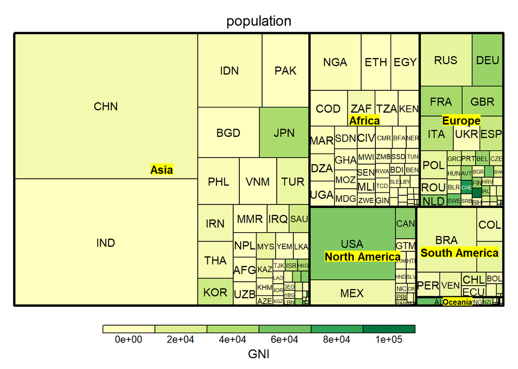

```r
treemap(GNI2014,
        index =c("continent","iso3"),
        vSize = "population",  #타일의 크기
        vColor = "GNI",        # 타일의 컬러
        type = "value",        # 타일 컬러링 방법
        bg.labels = "yellow")  # 레이블의 배경색색
```

```r
# 대륙별 인구, 소득
# 국가별 국민 총소득을 계산해서 GNI.total 칼럼에 저장
GNI2014$GNI.total <-
  GNI2014$population*GNI2014$GNI
head(GNI2014)
```

|  | iso3 | country | continent | population | GNI | GNI.total |
| --- | --- | --- | --- | --- | --- | --- |
| 3 | BMU | Bermuda | North America | 67837 | 106140 | 7200219180 |
| 4 | NOR | Norway | Europe | 4676305 | 103630 | 484605487150 |
| 5 | QAT | Qatar | Asia | 833285 | 92200 | 76828877000 |
| 6 | CHE | Switzerland | Europe | 7604467 | 88120 | 670105632040 |
| 7 | MAC | Macao SAR, China | Asia | 559846 | 76270 | 42699454420 |
| 8 | LUX | Luxembourg | Europe | 491775 | 75990 | 37369982250 |

```r
#국가별 국민 총소득을 대륙별로 합계내서 GNI2014,a에 저장
GNI2014.a <- aggregate(GNI2014[,4:6],
                       by=list(GNI2014$continent),sum)
```

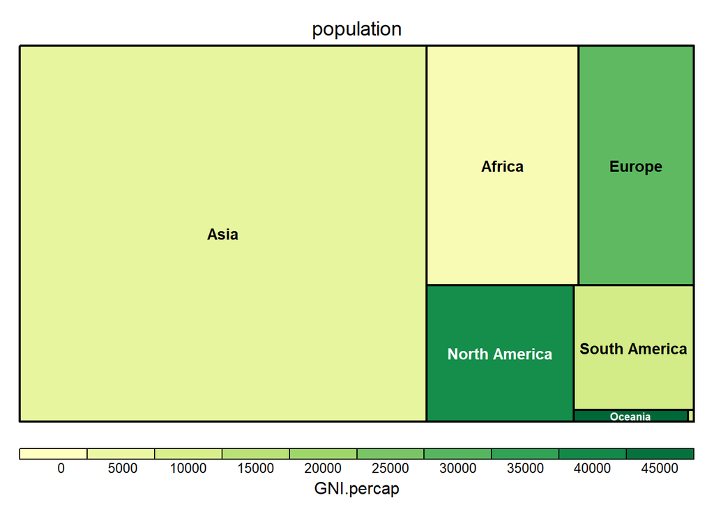

```r
#  대륙별 합계를 대륙 인구수로 나누어 GNI.percap칼럼에 저장
GNI2014.a$GNI.percap <-
  GNI2014.a$GNI.total/GNI2014.a$population

treemap(GNI2014.a,
        index = c("Group.1"),
        vSize = "population",
        vColor = "GNI.percap",
        type="value",
        bg.labels = "yellow")
```

2. 버블 차트(bubble chart)
- 산점도는 두개의 변수간 상관관꼐를 표시한다 *버블 차트는 산점도에 제3의 변수를 크기에 비례하는 버블(원)으로 표현

*설치가 필요한 패키지* MASS * 실습에 사용할 데이터 셋 *UScrime(MASS)

```r
library(MASS)
head(UScrime)
```

|  | M | So | Ed | Po1 | Po2 | LF | M.F | Pop | NW | U1 | U2 | GDP | Ineq | Prob | Time | y |
| --- | --- | --- | --- | --- | --- | --- | --- | --- | --- | --- | --- | --- | --- | --- | --- | --- |
| 1 | 151 | 1 | 91 | 58 | 56 | 510 | 950 | 33 | 301 | 108 | 41 | 394 | 261 | 0.084602 | 26.2011 | 791 |
| 2 | 143 | 0 | 113 | 103 | 95 | 583 | 1012 | 13 | 102 | 96 | 36 | 557 | 194 | 0.029599 | 25.2999 | 1635 |
| 3 | 142 | 1 | 89 | 45 | 44 | 533 | 969 | 18 | 219 | 94 | 33 | 318 | 250 | 0.083401 | 24.3006 | 578 |
| 4 | 136 | 0 | 121 | 149 | 141 | 577 | 994 | 157 | 80 | 102 | 39 | 673 | 167 | 0.015801 | 29.9012 | 1969 |
| 5 | 141 | 0 | 121 | 109 | 101 | 591 | 985 | 18 | 30 | 91 | 20 | 578 | 174 | 0.041399 | 21.2998 | 1234 |
| 6 | 121 | 0 | 110 | 118 | 115 | 547 | 964 | 25 | 44 | 84 | 29 | 689 | 126 | 0.034201 | 20.9995 | 682 |

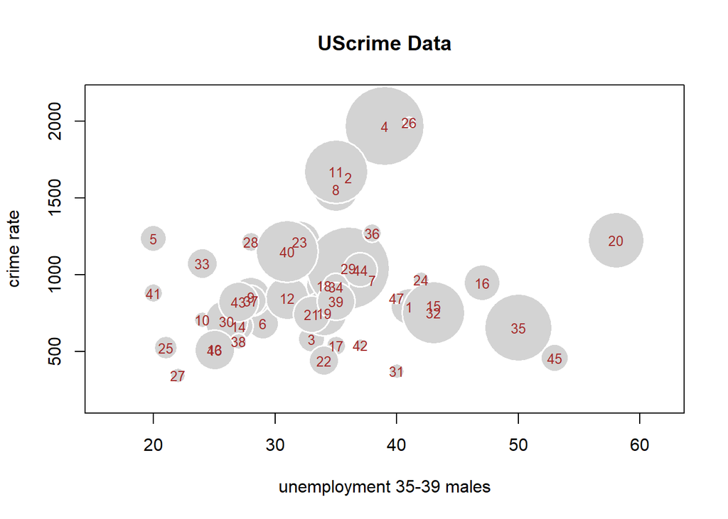

```r
radius <- sqrt(UScrime$Pop)   # 원의 반지름 (값이 커서 줄임)
symbols(UScrime$U2, UScrime$y, #원의 x,y 좌표값
        circles = radius,    #원의 반지름값
        inches=0.4,           #원의 크기 조절값
        fg = "white",         #원의 테두리 색
        bg = "lightgray",     # 원의 바탕색
        lwd=1.5,              # 원의 테두리선 두께
        xlab="unemployment 35-39 males",
        ylab = "crime rate",
        main="UScrime Data")
text(UScrime$U2, UScrime$y,   # 텍스트가 출력될 x,y좌표
     1:nrow(UScrime),         # 출력할 텍스트
     cex=0.8,                 # 폰트 크기
     col="brown")             # 폰트 color
```

다중 상자그림(Boxplot) * 상자그림(box plot)은 일변량 연속형 자료를 상자와 선, 그리고 점으로 표현한 그림 * 다중 상자 그림은 총 자료가 여러 개의 자료 묶음(data batch) 또는 그룹으로 구성되어 있는 경우 그룹 간 비교에 있어 시각적 효과가 탁월하다

- 실습에 사용할 데이터셋(2017년 서울 일별 평균기온) *Seoul_temp_2017.csv

```r
# setwd("c:/r_temp")
# ds <- read.csv("seoul_temp_2017.csv")
# head(ds)
# summary(ds$avg_temp)
#
# # 서울 1년 기온 분포
# boxplot(ds$avg_temp,
#         col="yellow",
#         ylim=c(-20,40),
#         xlab="서울1년기온",
#         ylab="기온")
```

모자이크 플롯(mosaic plot) * 모자이크플롯(mosaic plot)은 2원 3원 교차표의 시각화이다. 전체 정사각 도형을 교차표의 행 빈도에 비례하는 직사각 도형으로 나누고 다시 각 도형을 행 내 열의 빈도에 해당하는 직사각 도형으로 나눈다.

- 실습용 데이터셋 *mtcars* Titnic

```r
# 3차원 교차표 형태로 데이터가 존재하는 경우
Titanic
```

```
## , , Age = Child, Survived = No
##
##       Sex
## Class  Male Female
##   1st     0      0
##   2nd     0      0
##   3rd    35     17
##   Crew    0      0
##
## , , Age = Adult, Survived = No
##
##       Sex
## Class  Male Female
##   1st   118      4
##   2nd   154     13
##   3rd   387     89
##   Crew  670      3
##
## , , Age = Child, Survived = Yes
##
##       Sex
## Class  Male Female
##   1st     5      1
##   2nd    11     13
##   3rd    13     14
##   Crew    0      0
##
## , , Age = Adult, Survived = Yes
##
##       Sex
## Class  Male Female
##   1st    57    140
##   2nd    14     80
##   3rd    75     76
##   Crew  192     20
```

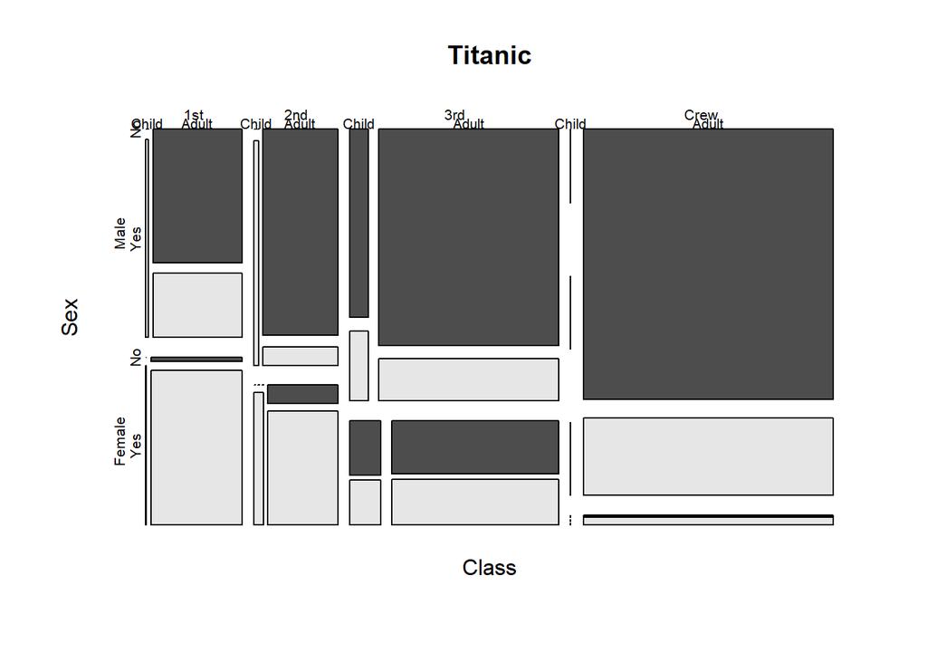

```r
mosaicplot(Titanic, color = TRUE, off=5)
```

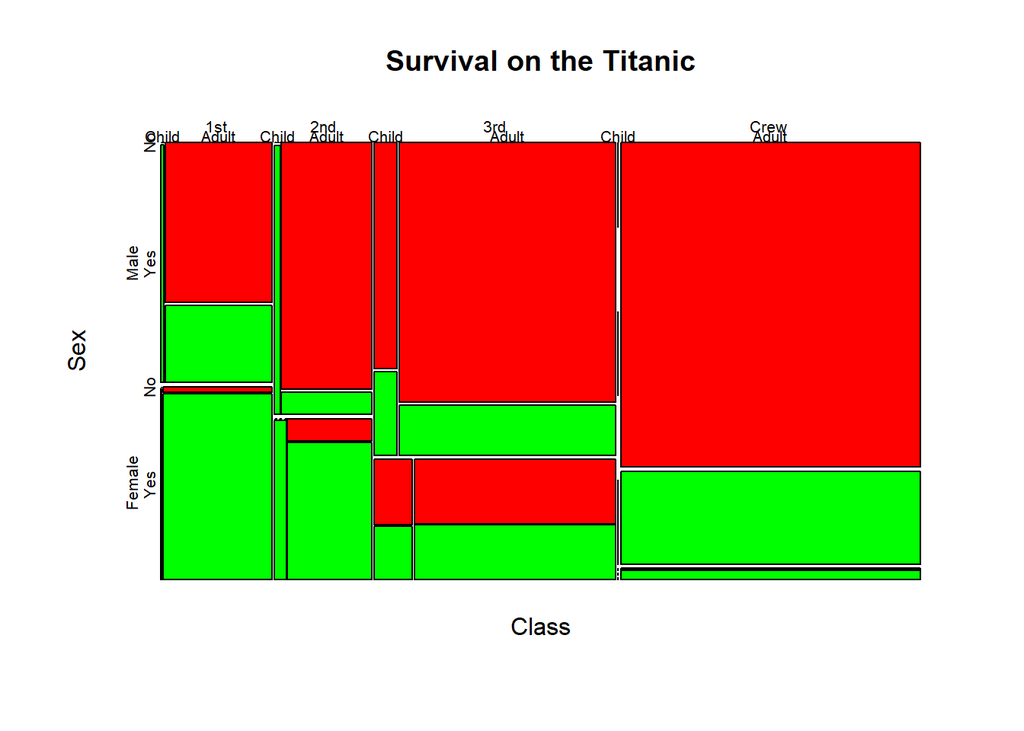

```r
 mosaicplot(Titanic,
            main = "Survival on the Titanic",
            color = c("red","green"),
            off=1)     #블럭들 사이의 간격 지정  #붉은색: 사망
```

```r
                                                 #연두색 생존
```